# **New or Used - Product Type**

# **Goal**

Report of the *Machine Learning* step, containing informations about the **training** process and the metrics to **evaluate** the final model. The main goal here is to build a ML model that is able to predict if the condition of a product **is (1) or not (0) new** (transformed feature, created on *EDA* second stage).

# **Environment**

Initially, we will carry out the **preparation of the work environment**, so that the dataset is ready to be modelled.

### **Importing Required Packages**

```python
import logging
import sys
import os
from warnings import filterwarnings
from random import choice
from math import sqrt
import pyarrow as pa
import pyarrow.parquet as pq
import pandas as pd
import numpy as np
from tabulate import tabulate
from itertools import zip_longest
import xgboost as xgb
from sklearn.metrics import log_loss, roc_curve, auc, accuracy_score, recall_score, precision_score
from sklearn.calibration import calibration_curve, CalibratedClassifierCV
from sklearn.model_selection import cross_validate
import seaborn as sns
import matplotlib.pyplot as plt
```

### **Funções do Projeto**

##### 1 - logger_config

```python
def logger_config():
    """
    Configurate logger format for monitoring steps in ML pipeline.
    """
    # Var logger
    logger = logging.getLogger("Logger")
    logger.setLevel(logging.DEBUG)
    # Criando formatter
    formatter = logging.Formatter('%(asctime)s - %(name)s - %(levelname)s - %(message)s')
    # Console handler para maior level no log e Adicionando formatter ao handler
    handler = logging.StreamHandler()
    handler.setLevel(logging.DEBUG)
    handler.setFormatter(formatter)
    # Adicionando handlers a feature 'logger'
    logger.addHandler(handler)
    # Retorno da funcao
    return logger
```

##### 2 - proportion_target_date

```python
def proportion_target_date(data: pd.DataFrame, target: str, date_column: str):
    """
    Build dataframe to analyze condition proportion over a time period.
    """
    try:
        # Group by target and date_column and count the occurrences
        count_by_condition_date = data.groupby([target, date_column]).size().reset_index(name='count_condition_date')
        # Sort by datetime
        count_by_condition_date = count_by_condition_date.sort_values(by=[date_column])
        # Count by date_column
        count_by_condition = data.groupby([date_column]).size().reset_index(name='count_date')
        # Merging dataframes to calculate percentage
        count_final = count_by_condition_date.merge(count_by_condition, on=date_column, how="left")
        # New column 'perc_condition_date'
        count_final["perc_condition_date"] = count_final["count_condition_date"]/count_final["count_date"]
        # Execution success log
        log.info("Create dataframe to analyze %s proportion over %s succesfully done!", target, date_column)
        # Return dataframe
        return count_final
    except ImportError:
        # Execution error log
        log.error(
            "Something went wrong... Could not create dataframe to analyze %s proportion over %s!", target, date_column
        )
```

##### 3 - ordinal_date_interval

```python
def ordinal_date_interval(data: pd.DataFrame, date_column: str):
    """
    Create ordinal split folds based on date_column.
    """
    try:
        # Creating a copy of the data
        dataset_with_truncated = data.copy()
        # Creating dataframe with unique values
        unique_intervals = pd.DataFrame(dataset_with_truncated[date_column].unique(), columns=[date_column])
        unique_intervals["ordinal_date"] = range(1, len(unique_intervals) + 1)
        # Join unique values with main dataframe
        dataset_with_truncated = dataset_with_truncated.merge(unique_intervals, on=date_column, how='left')
        # Sorting dataframe by date_column
        dataset_with_truncated = dataset_with_truncated.sort_values(date_column, ascending=True).reset_index(drop=True)
        # Execution success log
        log.info("Creating column for ordinal split folds succesfully done!")
        # Return dataframe result
        return dataset_with_truncated
    except ImportError:
        # Execution error log
        log.error("Something went wrong... Could not create column for ordinal split folds!")
```

##### 4 - create_custom_folds

```python
def create_custom_folds(data: pd.DataFrame, feature: str, lagged_interval: int):
    """
    Create custom folds for cross validation step.
    The CV folds has to respect the time effect over the features.
    """
    # Checking if variable is integer
    feature_type = (data[feature].dtype.kind in 'i')
    if feature_type == True:
        # Get max ordinal value from date interval
        max_ordinal_month = int(max(data[feature]))
        min_interval = max_ordinal_month - lagged_interval
        # If min_interval < 1, then min_interval = 1
        min_interval = max(min_interval, 1)
        # Creating custom_folds for cross validation
        list_train_fold = [
            np.array(
                data.index[
                    data[feature] <= n
                ].tolist()
            ) for n in range(min_interval, max_ordinal_month, 1)
        ]
        list_test_fold = [
            np.array(
                data.index[
                    data[feature] == n
                ].tolist()
            ) for n in range(min_interval + 1, max_ordinal_month + 1, 1)
        ]
        # Train and Test folds in the same list
        folds = list(zip(list_train_fold, list_test_fold))
        # Execution success log
        log.info("Custom folds from series '%s' in dataframe succesfully built!", feature)
    else:
        log.error("Feature '%s' is not from integer type!\nCould not create custom folds.", feature)
    # Returning results
    return folds
```

##### 5 - estimators_predictions

```python
def estimators_predictions(
    cross_val: dict, df_features: pd.DataFrame, y_from_data: pd.DataFrame, target: str, len_basis: int
):
    """
    Append predictions values from each
    estimator created in cross validation step in a list.
    """
    try:
        # Empty list for future store
        preds_list = []
        # Loop for predictions
        for i in range(0, len_basis):
            # Call estimator
            estimator_fold_n = cross_val["estimator"][i]
            # Predict probabilities for test index for each fold
            y_pred_fold_n = estimator_fold_n.predict_proba(
                df_features[(
                    df_features.ordinal_date == i + 2
                )].drop("ordinal_date", axis=1)
            )
            # Probability result of value = 1
            y_pred_fold_n = y_pred_fold_n[:, 1]
            # Extract true value from the test set
            y_true = y_from_data.filter(
                items=np.array(
                    y_from_data.index[
                        y_from_data["ordinal_date"] == i + 2
                    ]
                ).tolist(), axis=0
            )[target]
            # Binding results
            y_results = pd.DataFrame({
                'predictions': y_pred_fold_n,
                'true': y_true
            })
            # Append values to list
            preds_list.append(y_results)
        # Execution success log
        log.info("Append predictions for each estimator succesfully done!")
        # Return results from list
        return preds_list
    except ImportError:
        # Execution error log
        log.error("Something went wrong... Could not append predictions for each estimator!")
```

##### 6 - dumb_log_loss

```python
def dumb_log_loss(class_ratio: list, multi=100):
    """
    Input a list of ratios of your classes and
    outputs a random guessing log-loss.
    """
    try:
        if sum(class_ratio)!=1.0:
            log.warning("Sum of ratios should be 1 for best results")
            class_ratio[-1]+=1-sum(class_ratio)
        actuals=[]
        for i,val in enumerate(class_ratio):
            actuals=actuals+[i for x in range(int(val*multi))]
        preds=[]
        for i in range(multi):
            preds+=[class_ratio]
        # Execution success log
        log.info("Succesfully calculated dumb log loss based on class_ratios %s!", class_ratio)
        return log_loss(actuals, preds)
    except ImportError:
        # Execution error log
        log.error("Something went wrong... Could not calculate dumb log loss based on class_ratios %s!", class_ratio)
```

##### 7 - metrics_from_cv

```python
def metrics_from_cv(cross_val: dict, metrics: list, title: str):
    """
    Print metrics result from cross validation process.
    """
    try:
        # Print of the analyzed dataset
        print(f"'{title}' set metrics results:\n")
        # For each metric...
        for i in metrics:
            # Extract mean value and standard deviation
            result_train = cross_val[f"train_{i}"].mean()
            result_test = cross_val[f"test_{i}"].mean()
            std_train = cross_val[f"train_{i}"].std() * 2
            std_test = cross_val[f"test_{i}"].std() * 2
            # Printing results
            print(f"train_{i}: {result_train:0.3f} (+/-{std_train:0.3f})")
            print(f"test_{i}: {result_test:0.3f} (+/-{std_test:0.3f})")
        # Execution success log
        log.info("Succesfully print metrics from CV results!")
    except ImportError:
        # Execution error log
        log.error("Something went wrong... Could not print metrics from CV results!")
```

##### 8 - test_dumb_comparative

```python
def test_dumb_comparative(cross_val: dict, dumb_ratio:list):
    """
    Check if log loss from test set is lower than the dumb log loss value.
    """
    try:
        # Declaring logloss values
        test_logloss = -cross_val["test_neg_log_loss"].mean()
        dumb_logloss = dumb_log_loss(dumb_ratio)
        # Comparing to 'dumb_log_loss'
        if dumb_logloss > test_logloss:
            print(f"\n(OKAY <> Test set Logloss average {test_logloss:0.3f} from model \
is lower than {dumb_logloss:0.3f} from random guessing.)")
        else:
            print(f"\n(WARNING <> Test set Logloss average {test_logloss:0.3f} from model \
is greater than {dumb_logloss:0.3f} from random guessing.)")
        # Execution success log
        log.info("Succesfully log loss comparative!")
    except ImportError:
        # Execution error log
        log.error("Something went wrong... Could not print log loss comparative!")
```

##### 9 - plot_metrics_by_fold

```python
def plot_metrics_by_fold(folds_list: list, metrics: list, cross_val_1: dict, cross_val_2: dict, set_str: str):
    """
    Plot metrics result from cross validation process by each fold.
    """
    try:
        # Creating grid output layout
        fig, axes = plt.subplots(1, 2, figsize=(18, 5))
        # For each metric...
        for i in metrics:
            # Metric evolution for each fold in cv1
            sns.lineplot(
                ax=axes[metrics.index(i)],
                x=folds_list,
                y=cross_val_1[f"{set_str}_{i}"],
                color='red',
                marker='o'
            ).set(title=f"Metric in {set_str} - {i}")
            # Metric evolution for each fold in cv1
            sns.lineplot(
                ax=axes[metrics.index(i)],
                x=folds_list,
                y=cross_val_2[f"{set_str}_{i}"],
                color='black',
                marker='o'
            ).set(title=f"Metric in {set_str} - {i}")
            # Plotando legenda das imagens
            axes[metrics.index(i)].legend(["Uncalibrated", "Calibrated"], loc='lower right')
        # Execution success log
        log.info("Succesfully create plots from CV metrics!")
    except ImportError:
        # Execution error log
        log.error("Something went wrong... Could not create plots from CV metrics!")
```

##### 10 - plot_auc_roc

```python
def plot_auc_roc(pred_list: list, title: str, ax, color: list):
    """
    Creating AUC/ROC Curve plot for each fold prediction.
    """
    try:
        # Loop to extract each dataframe from list
        for (i, results), color_unit in zip(enumerate(pred_list), color):
            predictions = results["predictions"]
            true = results["true"]
            # Metrics to evaluate model
            fpr, tpr, threshold = roc_curve(true, predictions)
            roc_auc = auc(fpr, tpr)
            # Plot ROC Curve
            ax.set_title(f'AUC/ROC Curve - {title} Model')
            ax.plot(fpr, tpr, 'b', label = f'Fold {i + 1} = {roc_auc:0.3f}', c=color_unit)
            ax.legend(loc = 'lower right')
            ax.plot([0, 1], [0, 1], color='lightgrey', linestyle='dashed')
            ax.set_xlim([0, 1])
            ax.set_ylim([0, 1])
            ax.set_ylabel('True Positive Rate')
            ax.set_xlabel('False Positive Rate')
        # Execution success log
        log.info("Succesfully create AUC/ROC Curve plot for '%s' model!", title)
        # Return result of plot
        return ax
    except ImportError:
        # Execution error log
        log.error("Something went wrong... Could not create AUC/ROC Curve plot for '%s' model!", title)
```

##### 11 - plot_calibrated_curve

```python
def plot_calibrated_curve(pred_list: list, title: str, ax, color: list):
    """
    Plot probability calibration curve for a specific prediction set.
    """
    try:
        # Loop to extract each dataframe from list
        for (i, results), color_unit in zip(enumerate(pred_list), color):
            predictions = results["predictions"]
            true = results["true"]
            # Creating calibration curves
            fop, mpv = calibration_curve(true, predictions, n_bins=10)
            # Plot test results
            ax.set_title(f'Calibrated Curve - {title} Model')
            ax.plot(mpv, fop, marker='.', label = f'Fold {i + 1}', c=color_unit)
            ax.legend(loc = 'lower right')
            ax.set_xlim([0, 1])
            ax.set_ylim([0, 1])
            ax.set_ylabel('Fraction of Positives (Positive Class: 1)')
            ax.set_xlabel('Mean Predicted Probability (Positive Class: 1)')
            # Add the 'perfect' curve
            ax.plot([0, 1], [0, 1], color='lightgrey', linestyle='dashed')
        # Execution success log
        log.info("Succesfully create Calibration Curve plot for '%s' model!", title)
        # Return plot result
        return ax
    except ImportError:
        # Execution error log
        log.error("Something went wrong... Could not create Calibration Curve plot for '%s' model!", title)
```

##### 12 - proba_histograms

```python
def proba_histograms(pred_list: list):
    """
    Plot histogram to check for predictions probabilities distribution.
    """
    try:
        # Create subplots
        fig, axs = plt.subplots(nrows=1, ncols=len(pred_list), figsize=(12, 5), sharey=True)
        # For loop to itterate over predictions
        for fold in range(0, len(pred_list)):
            # Plot histograms for each series
            axs[fold].hist(pred_list[fold]["predictions"], bins=10, color='blue', edgecolor='black')
            # Add components of the plot
            axs[fold].yaxis.grid(True, color='black', linestyle='--')
            axs[fold].set_title(f'Predictions Histogram - Fold {fold + 1}')
            axs[fold].set_ylabel('Count')
            axs[fold].set_xlabel('is_condition_new predictions')
        # Log de execucao com sucesso
        log.info("Histogram plot from predictions succesfully done!")
        # Show the plot
        return plt.show()
    except ImportError:
        # Log de erro na execucao
        log.error("Something went wrong... Could not plot histogram from predictions.")
```

### **Settings**

##### Config options

```python
# Declare logger default
log = logger_config()

# Filtering to suppress warnings
filterwarnings("ignore")

# Display pandas formats
pd.set_option('display.max_columns', None)
pd.set_option('display.float_format', lambda x: '%.2f' % x)

# Dimensions of the plots
plt.rcParams['figure.figsize'] = [10, 6]
```

##### Loading parquet file as pandas dataframe

```python
# Loading dataset
try:
    # Importing ml parquet file
    ml_new_or_used = pq.read_table(
        os.path.join(os.getcwd(), 'outputs', "ml_new_or_used.parquet"),
    )
    # Convert the PyArrow table to a Pandas DataFrame
    ml_new_or_used = ml_new_or_used.to_pandas()
    # Execution success log
    log.info("Read parquet file as a pandas dataframe succesfully done!")
except ImportError:
    # Execution error log
    log.error("Something went wrong... Could not read parquet file as a pandas dataframe!")
```

```
2023-02-28 12:47:31,351 - Logger - INFO - Read parquet file as a pandas dataframe succesfully done!
```

##### Remembering our dataframe structure

```python
# Showing some rows of the dataframe previously saved
ml_new_or_used.head(5)
```

|  | id | date_mon_day_interval | is_condition_new | listing__bronze | listing__free | listing__gold | listing__gold_special | listing__silver | has_oficial_in_warranty | has_fabrica_in_warranty | has_6_in_warranty | has_12_in_warranty | has_meses_in_warranty | has_defectos_in_warranty | has_nuevo_in_warranty | has_solo_in_warranty | has_1_in_warranty | has_3_in_warranty | has_tiene_in_warranty | has_garantia_in_warranty | has_fallas_in_warranty | has_calidad_in_warranty | has_caso_in_warranty | has_dias_in_warranty | has_original_in_warranty | has_cambio_in_warranty | has_entrega_in_warranty | has_comprador_in_warranty | has_total_in_warranty | … |
| --- | --- | --- | --- | --- | --- | --- | --- | --- | --- | --- | --- | --- | --- | --- | --- | --- | --- | --- | --- | --- | --- | --- | --- | --- | --- | --- | --- | --- | --- | --- |
| 0 | MLA5569012823 | 2015-08-2 | 1 | 1 | 0 | 0 | 0 | 0 | 0 | 0 | 0 | 0 | 0 | 0 | 0 | 0 | 0 | 0 | 0 | 0 | 0 | 0 | 0 | 0 | 0 | 0 | 0 | 0 | 0 | … |
| 1 | MLA9192261615 | 2015-08-2 | 0 | 0 | 1 | 0 | 0 | 0 | 0 | 0 | 0 | 0 | 0 | 0 | 0 | 0 | 0 | 0 | 0 | 0 | 0 | 0 | 0 | 0 | 0 | 0 | 0 | 0 | 0 | … |
| 2 | MLA5452317212 | 2015-08-2 | 1 | 1 | 0 | 0 | 0 | 0 | 0 | 0 | 0 | 0 | 0 | 0 | 0 | 0 | 0 | 0 | 0 | 0 | 0 | 0 | 0 | 0 | 0 | 0 | 0 | 0 | 0 | … |
| 3 | MLA5598508186 | 2015-08-2 | 1 | 1 | 0 | 0 | 0 | 0 | 0 | 0 | 0 | 0 | 0 | 0 | 0 | 0 | 0 | 0 | 0 | 0 | 0 | 0 | 0 | 0 | 0 | 0 | 0 | 0 | 0 | … |
| 4 | MLA4325647900 | 2015-08-2 | 0 | 0 | 1 | 0 | 0 | 0 | 0 | 0 | 0 | 0 | 0 | 0 | 0 | 0 | 0 | 0 | 0 | 0 | 0 | 0 | 0 | 0 | 0 | 0 | 0 | 0 | 0 | … |

# **Modelling**

Having knowledge of the approach mentioned in the **Data Wrangling file** (*dwr.ipynb*), here we will talk in more depth about the working methodology for model **training and evaluation**.

Despite the **"obligation"** to obtain a result of 86% or more for Accuracy, we know that this type of metric is EXTREMELY SENSITIVE to the defined **threshold**, as well as any metric based on predicted classes. In this sense, we will first **calibrate the output scores 0-1**, in order to make the SCORE CLOSER TO THE REAL PROBABILITY that the record is in the class 0 or 1.

In this way, we will have **more confidence** in selecting a threshold for setting 0/1, being closer to a real probability.

When we have this, we will find the results for the **Accuracy** metric and also for **Precision**, chosen as the second ideal metric for optimization. Your choice is also based on the approach initially discussed, when we want to *prevent products with the used condition from being classified as new* in order to reduce customers **bad experiences** (avoid *false positives*).

### **Create a copy**

```python
ml_set = ml_new_or_used.copy()
```

### **Class Proportion over time**

```python
# Remembering proportion of 0's and 1's over date interval
proportion = proportion_target_date(
    data=ml_set,
    target="is_condition_new",
    date_column="date_mon_day_interval"
)

# Print result
proportion
```

```
2023-02-28 12:47:31,738 - Logger - INFO - Create dataframe to analyze is_condition_new proportion over date_mon_day_interval succesfully done!
```

|  | is_condition_new | date_mon_day_interval | count_condition_date | count_date | perc_condition_date |
| --- | --- | --- | --- | --- | --- |
| 0 | 0 | 2015-08-2 | 10510 | 22483 | 0.47 |
| 1 | 1 | 2015-08-2 | 11973 | 22483 | 0.53 |
| 2 | 0 | 2015-09-1 | 10603 | 23142 | 0.46 |
| 3 | 1 | 2015-09-1 | 12539 | 23142 | 0.54 |
| 4 | 0 | 2015-09-2 | 11879 | 25336 | 0.47 |
| 5 | 1 | 2015-09-2 | 13457 | 25336 | 0.53 |
| 6 | 0 | 2015-10-1 | 12445 | 27361 | 0.45 |
| 7 | 1 | 2015-10-1 | 14916 | 27361 | 0.55 |

**Comments**: Classes are **almost perfectly balanced**, both in historical averages and over time. In this case, we will not perform any treatment to deal with this "class imbalance".

### **Custom Folds**

##### Creating ordinal column for folds

```python
# Ordinal feature grouped by date_column
ml_set = ordinal_date_interval(
    data=ml_set,
    date_column="date_mon_day_interval"
)
```

```
2023-02-28 12:47:32,139 - Logger - INFO - Creating column for ordinal split folds succesfully done!
```

```python
# Printing results
print(
    tabulate(
        zip_longest(
            list(ml_set["date_mon_day_interval"].unique()),
            list(ml_set["ordinal_date"].unique()),
            fillvalue=''),
        headers=['date_list', 'ordinal_list'],
        tablefmt="double_grid"
    )
)
```

```
╔═════════════╦════════════════╗
║ date_list   ║   ordinal_list ║
╠═════════════╬════════════════╣
║ 2015-08-2   ║              1 ║
╠═════════════╬════════════════╣
║ 2015-09-1   ║              2 ║
╠═════════════╬════════════════╣
║ 2015-09-2   ║              3 ║
╠═════════════╬════════════════╣
║ 2015-10-1   ║              4 ║
╚═════════════╩════════════════╝
```

**Comments**: Here, the *folds* that will compose the **Cross Validation** step were created, following the unique values of the column 'date_mon_day_interval'. The *rolling basis* logic will be used to separate the *folds*.

##### Building list with folds for CV

```python
# Store folds in a list
custom_folds = create_custom_folds(
    data=ml_set,
    feature="ordinal_date",
    lagged_interval=3
)
```

```
2023-02-28 12:47:32,414 - Logger - INFO - Custom folds from series 'ordinal_date' in dataframe succesfully built!
```

```python
# Display results
custom_folds
```

```
[(array([    0,     1,     2, ..., 22480, 22481, 22482]),
  array([22483, 22484, 22485, ..., 45622, 45623, 45624])),
 (array([    0,     1,     2, ..., 45622, 45623, 45624]),
  array([45625, 45626, 45627, ..., 70958, 70959, 70960])),
 (array([    0,     1,     2, ..., 70958, 70959, 70960]),
  array([70961, 70962, 70963, ..., 98319, 98320, 98321]))]
```

**Comments**: So these will be the **folds of my Cross-Validation** process, where in my first pair of arrays, for example, I have the *2015-08-2* date interval for **training** and *2015-09-1* for **testing** on **fold 1** and, as time goes by, new intervals are being **added to the training process**, limiting the number of intervals for training to the LAST 3, causing very old data TO BE DISCARTED from the training process (here, considering new data arriving from production environment).

### **Estrutura do Dado**

##### Preditors & Target

```python
try:
    """ Dataframe with features and series with target.
    PS: Custom fold feature will be featured removed.
    Has to be passed as an argument before """
    # Remove unused columns
    x_data = ml_set.drop(
        [
            "id",
            "date_mon_day_interval",
            "is_condition_new",
        ], axis=1)
    y_target = ml_set["is_condition_new"]
    # Execution success log
    log.info("Dataframe with preditors and array with target values succesfully built!")
except ImportError:
    # Execution error log
    log.error("Something went wrong... Could not create preditors dataframe and array with target values!")
```

```
2023-02-28 12:47:32,644 - Logger - INFO - Dataframe with preditors and array with target values succesfully built!
```

### **Model**

To prove how calibrated models have greater confidence in defining the threshold in relation to uncalibrated models, we will train BOTH SCENARIOS and check metrics such as **AUC/ROC Curve** and **Logloss** values to evaluate our probabilities and analyze some pros and cons for calibrating models.

It's my practice as a Data Scientist not to waste too much time choosing "THE BEST ALGORITHM" to work with or searching for the "OPTIMIZED PARAMETERS". I follow the philosophy that the gain in the process of building *Machine Learning models* comes with a good selection of records & discriminant variables, a well-structured feature engineering and a good model calibration.

Furthermore, I believe that a Data Scientist SHOULD BE AWARE of the **hyperparameters used** and choose according to a **rationale**, instead of setting a grid and letting the machine select the best values. It's better to "lose" in METRICS VALUES, but know how to explain **why your model is performing this way and generalize as much as possible**.

Therefor, the algorithm chosen a priori was the **XGBoost**, with some parameters set based on my *ml dataset dimmensions*.

##### Parameters and Initial Fit

```python
try:
    # Input parameters
    input_parameters = {
        "objective": str('binary:logistic'),
        "eta": float(0.1),
        "subsample": float(0.75),
        "gamma": float(1.0),
        "lambda": float(1.0),
        "alpha": float(1.0),
        "max_depth": int(5),
        "min_child_weight": int(10),
        "eval_metric": [
            'logloss',
            'auc'
        ],
        "n_estimators": int(250),
        "n_jobs": int(-1)
    }
    # Creating classifier
    classifier_xgb = xgb.XGBClassifier(**input_parameters)
    # Fitting the model
    xgb_model = classifier_xgb.fit(
        X=x_data.drop(["ordinal_date"], axis=1),
        y=y_target
    )
    # Execution success log
    log.info("XGBoost initial model succesfully fitted!")
except ImportError:
    # Execution error log
    log.error("Something went wrong... Could not fit XGBoost initial model.")
```

```
2023-02-28 12:48:01,975 - Logger - INFO - XGBoost initial model succesfully fitted!
```

```python
# Printing the classifier
print(xgb_model)
```

```
XGBClassifier(alpha=1.0, base_score=0.5, booster='gbtree', colsample_bylevel=1,
              colsample_bynode=1, colsample_bytree=1, enable_categorical=False,
              eta=0.1, eval_metric=['logloss', 'auc'], gamma=1.0, gpu_id=-1,
              importance_type=None, interaction_constraints='', lambda=1.0,
              learning_rate=0.100000001, max_delta_step=0, max_depth=5,
              min_child_weight=10, missing=nan, monotone_constraints='()',
              n_estimators=250, n_jobs=-1, num_parallel_tree=1,
              predictor='auto', random_state=0, reg_alpha=1, reg_lambda=1,
              scale_pos_weight=1, subsample=0.75, tree_method='exact', ...)
```

##### Cross Validation in not calibrated model

```python
try:
    # Using cv in first model, based on custom folds,
    # returning results and the estimators for each fold
    score_metrics = ['roc_auc', 'neg_log_loss']
    xgb_cv_results = cross_validate(
        estimator=xgb_model,
        X=x_data.drop(["ordinal_date"], axis=1),
        y=y_target,
        cv=custom_folds,
        scoring=score_metrics,
        return_estimator=True,
        return_train_score=True
    )
    # Execution success log
    log.info("Cross validate XGBoost initial model succesfully done!")
except ImportError:
    # Execution error log
    log.error("Something went wrong... Could not cross validate XGBoost initial model.")
```

```
2023-02-28 12:48:49,370 - Logger - INFO - Cross validate XGBoost initial model succesfully done!
```

```python
# Estimators from Not Calibrated model in the CV process
xgb_cv_results["estimator"]
```

```
[XGBClassifier(alpha=1.0, base_score=0.5, booster='gbtree', colsample_bylevel=1,
               colsample_bynode=1, colsample_bytree=1, enable_categorical=False,
               eta=0.1, eval_metric=['logloss', 'auc'], gamma=1.0, gpu_id=-1,
               importance_type=None, interaction_constraints='', lambda=1.0,
               learning_rate=0.100000001, max_delta_step=0, max_depth=5,
               min_child_weight=10, missing=nan, monotone_constraints='()',
               n_estimators=250, n_jobs=-1, num_parallel_tree=1,
               predictor='auto', random_state=0, reg_alpha=1, reg_lambda=1,
               scale_pos_weight=1, subsample=0.75, tree_method='exact', ...),
 XGBClassifier(alpha=1.0, base_score=0.5, booster='gbtree', colsample_bylevel=1,
               colsample_bynode=1, colsample_bytree=1, enable_categorical=False,
               eta=0.1, eval_metric=['logloss', 'auc'], gamma=1.0, gpu_id=-1,
               importance_type=None, interaction_constraints='', lambda=1.0,
               learning_rate=0.100000001, max_delta_step=0, max_depth=5,
               min_child_weight=10, missing=nan, monotone_constraints='()',
               n_estimators=250, n_jobs=-1, num_parallel_tree=1,
               predictor='auto', random_state=0, reg_alpha=1, reg_lambda=1,
               scale_pos_weight=1, subsample=0.75, tree_method='exact', ...),
 XGBClassifier(alpha=1.0, base_score=0.5, booster='gbtree', colsample_bylevel=1,
               colsample_bynode=1, colsample_bytree=1, enable_categorical=False,
               eta=0.1, eval_metric=['logloss', 'auc'], gamma=1.0, gpu_id=-1,
               importance_type=None, interaction_constraints='', lambda=1.0,
               learning_rate=0.100000001, max_delta_step=0, max_depth=5,
               min_child_weight=10, missing=nan, monotone_constraints='()',
               n_estimators=250, n_jobs=-1, num_parallel_tree=1,
               predictor='auto', random_state=0, reg_alpha=1, reg_lambda=1,
               scale_pos_weight=1, subsample=0.75, tree_method='exact', ...)]
```

**Comments**: Here, we have the defined parameters of the estimators for **each fold** in our *Uncalibrated Model*.

##### Calibrating Probabilities

```python
try:
    # Applying calibrator to the model
    xgb_classifier_calibrated = CalibratedClassifierCV(
        estimator=xgb_model,
        method='isotonic',
        cv=5,
        ensemble=True
    )
    # Metrics in calibrated model from CV process
    xgb_cv_results_calibrated = cross_validate(
        estimator=xgb_classifier_calibrated,
        X=x_data.drop(["ordinal_date"], axis=1),
        y=y_target,
        cv=custom_folds,
        scoring=score_metrics,
        return_estimator=True,
        return_train_score=True
    )
    # Fitting the calibrated model
    xgb_model_calibrated = xgb_classifier_calibrated.fit(
        X=x_data.drop(["ordinal_date"], axis=1),
        y=y_target
    )
    # Execution success log
    log.info("Calibrating probabilities in a new XGBoost model succesfully done!")
except ImportError:
    # Execution error log
    log.error("Something went wrong... Could not calibrate probabilities.")
```

```
2023-02-28 12:54:07,688 - Logger - INFO - Calibrating probabilities in a new XGBoost model succesfully done!
```

```python
# Estimators from Calibrated model in the CV process
xgb_cv_results_calibrated["estimator"]
```

```
[CalibratedClassifierCV(cv=5,
                        estimator=XGBClassifier(alpha=1.0, base_score=0.5,
                                                booster='gbtree',
                                                colsample_bylevel=1,
                                                colsample_bynode=1,
                                                colsample_bytree=1,
                                                enable_categorical=False,
                                                eta=0.1,
                                                eval_metric=['logloss', 'auc'],
                                                gamma=1.0, gpu_id=-1,
                                                importance_type=None,
                                                interaction_constraints='',
                                                lambda=1.0,
                                                learning_rate=0.100000001,
                                                max_delta_step=0, max_depth=5,
                                                min_child_weight=10, missing=nan,
                                                monotone_constraints='()',
                                                n_estimators=250, n_jobs=-1,
                                                num_parallel_tree=1,
                                                predictor='auto', random_state=0,
                                                reg_alpha=1, reg_lambda=1,
                                                scale_pos_weight=1,
                                                subsample=0.75,
                                                tree_method='exact', ...),
                        method='isotonic'),
 CalibratedClassifierCV(cv=5,
                        estimator=XGBClassifier(alpha=1.0, base_score=0.5,
                                                booster='gbtree',
                                                colsample_bylevel=1,
                                                colsample_bynode=1,
                                                colsample_bytree=1,
                                                enable_categorical=False,
                                                eta=0.1,
                                                eval_metric=['logloss', 'auc'],
                                                gamma=1.0, gpu_id=-1,
                                                importance_type=None,
                                                interaction_constraints='',
                                                lambda=1.0,
                                                learning_rate=0.100000001,
                                                max_delta_step=0, max_depth=5,
```

[output cut: 20 more lines]

```
                                                importance_type=None,
                                                interaction_constraints='',
                                                lambda=1.0,
                                                learning_rate=0.100000001,
                                                max_delta_step=0, max_depth=5,
                                                min_child_weight=10, missing=nan,
                                                monotone_constraints='()',
                                                n_estimators=250, n_jobs=-1,
                                                num_parallel_tree=1,
                                                predictor='auto', random_state=0,
                                                reg_alpha=1, reg_lambda=1,
                                                scale_pos_weight=1,
                                                subsample=0.75,
                                                tree_method='exact', ...),
                        method='isotonic')]
```

**Comments**: We do the same cross-validation process to **calibrate** our model.

# **Evaluate Model - Probabilities**

##### Predicts by Folds

The rationale will be to evaluate the *predicts* performed on the test sets for each *fold*, comparing values of some metrics between the models **Not Calibrated** *vs* **Calibrated**.

```python
# Predict of each estimator trained in CV step
# 1 - Not Calibrated Model
uncalibrated_preds = estimators_predictions(
    cross_val=xgb_cv_results,
    df_features=x_data,
    y_from_data=ml_set,
    target="is_condition_new",
    len_basis=len(custom_folds)
)
# 2 - Calibrated Model
calibrated_preds = estimators_predictions(
    cross_val=xgb_cv_results_calibrated,
    df_features=x_data,
    y_from_data=ml_set,
    target="is_condition_new",
    len_basis=len(custom_folds)
)
```

```
2023-02-28 12:54:08,330 - Logger - INFO - Append predictions for each estimator succesfully done!
2023-02-28 12:54:09,414 - Logger - INFO - Append predictions for each estimator succesfully done!
```

##### Predictions Analysis

Global Metrics Average

```python
print("\n")

# Store avg proportion for each class in a list
prop_list = proportion.groupby('is_condition_new')['perc_condition_date'].mean().round(2).tolist()

# Printing metrics from models
# 1 - Not Calibrated
metrics_from_cv(
    cross_val=xgb_cv_results,
    metrics=score_metrics,
    title='Uncalibrated'
)

test_dumb_comparative(cross_val=xgb_cv_results, dumb_ratio=prop_list)

DIVISOR_MARK = "-" * 50
print(f"\n\n{DIVISOR_MARK}\n\n")

# 2 - Calibrated
metrics_from_cv(
    cross_val=xgb_cv_results_calibrated,
    metrics=score_metrics,
    title='Calibrated'
)

test_dumb_comparative(cross_val=xgb_cv_results_calibrated, dumb_ratio=prop_list)
```

```
2023-02-28 12:54:09,525 - Logger - INFO - Succesfully print metrics from CV results!
2023-02-28 12:54:09,527 - Logger - INFO - Succesfully calculated dumb log loss based on class_ratios [0.46, 0.54]!
2023-02-28 12:54:09,536 - Logger - INFO - Succesfully log loss comparative!
2023-02-28 12:54:09,539 - Logger - INFO - Succesfully print metrics from CV results!
2023-02-28 12:54:09,541 - Logger - INFO - Succesfully calculated dumb log loss based on class_ratios [0.46, 0.54]!
2023-02-28 12:54:09,545 - Logger - INFO - Succesfully log loss comparative!
```

```
'Uncalibrated' set metrics results:

train_roc_auc: 0.918 (+/-0.001)
test_roc_auc: 0.912 (+/-0.007)
train_neg_log_loss: -0.347 (+/-0.002)
test_neg_log_loss: -0.360 (+/-0.012)

(OKAY <> Test set Logloss average 0.360 from model is lower than 0.690 from random guessing.)


--------------------------------------------------


'Calibrated' set metrics results:

train_roc_auc: 0.917 (+/-0.001)
test_roc_auc: 0.911 (+/-0.007)
train_neg_log_loss: -0.347 (+/-0.002)
test_neg_log_loss: -0.363 (+/-0.015)

(OKAY <> Test set Logloss average 0.363 from model is lower than 0.690 from random guessing.)
```

**Comments**: Overall, the results were virtually **identical** and **very satisfying** at first sight. There is a slight difference in **standard deviation across the test set** (which is expected), but the results are close without indicating **overfitting**.

Global metrics by Fold

```
2023-02-28 12:54:10,031 - Logger - INFO - Succesfully create plots from CV metrics!
2023-02-28 12:54:10,233 - Logger - INFO - Succesfully create plots from CV metrics!
```

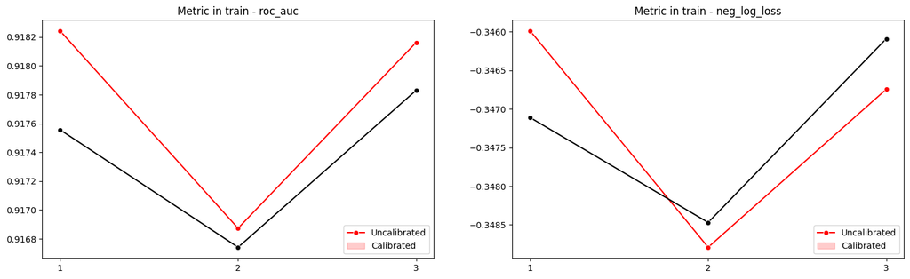

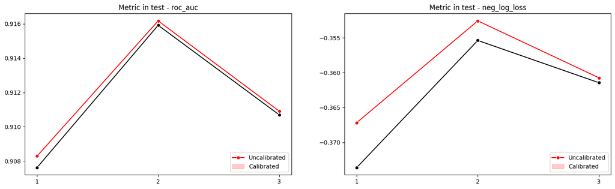

```python
# Folds number in a list
folds_n = list(ml_set.ordinal_date.drop_duplicates().astype('str'))[: -1]

# Plots from metrics in every fold
# 1 - train
plot_metrics_by_fold(
    folds_list=folds_n,
    metrics=score_metrics,
    cross_val_1=xgb_cv_results,
    cross_val_2=xgb_cv_results_calibrated,
    set_str='train'
)
# 2 - test
plot_metrics_by_fold(
    folds_list=folds_n,
    metrics=score_metrics,
    cross_val_1=xgb_cv_results,
    cross_val_2=xgb_cv_results_calibrated,
    set_str='test'
)
```

**Comments**: Analyzing fold-by-fold in train and test set, we see that the calibrated model **approaches** the values of the uncalibrated model (especially on the **last fold**, with more training data). Despite the metrics being very close, with a calibrated model we are more certain that the output scores are in fact MORE RELATED TO 0-1 PROBABILITIES.

AUC/ROC Curve

Let's see the shape of the ROC & Calibration curves for each fold.

```
2023-02-28 12:54:11,551 - Logger - INFO - Succesfully create AUC/ROC Curve plot for 'Uncalibrated' model!
2023-02-28 12:54:11,601 - Logger - INFO - Succesfully create AUC/ROC Curve plot for 'Calibrated' model!
```

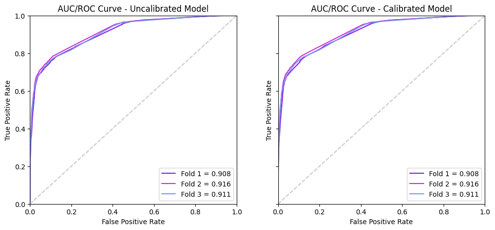

```python
# Generate random colors in a list
color_list=["#"+''.join([choice('0123456789ABCDEF') for j in range(6)]) for i in range(0, len(uncalibrated_preds))]

# Plotting AUC/ROC curve
fig, axes = plt.subplots(nrows=1, ncols=2, figsize=(12, 5), sharey=True)
plot_auc_roc(pred_list=uncalibrated_preds, title='Uncalibrated', ax=axes[0], color=color_list)
plot_auc_roc(pred_list=calibrated_preds, title='Calibrated', ax=axes[1], color=color_list)
fig.show()
```

Calibrated Curve

```
2023-02-28 12:54:12,418 - Logger - INFO - Succesfully create Calibration Curve plot for 'Uncalibrated' model!
2023-02-28 12:54:12,436 - Logger - INFO - Succesfully create Calibration Curve plot for 'Calibrated' model!
```

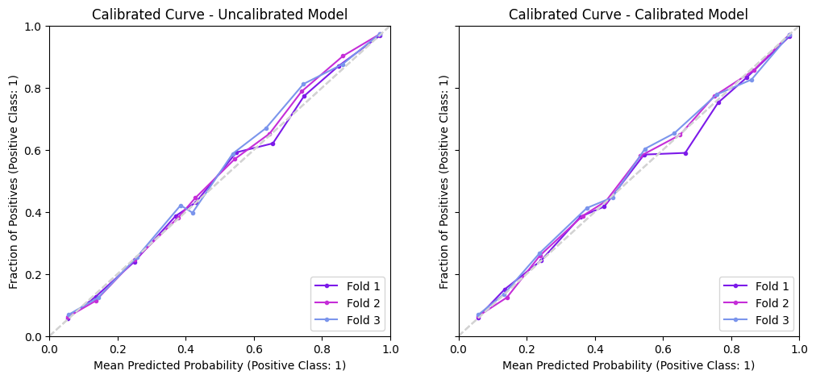

```python
# Plotting calibration curves
fig, axes = plt.subplots(nrows=1, ncols=2, figsize=(12, 5), sharey=True)
plot_calibrated_curve(pred_list=uncalibrated_preds, title='Uncalibrated', ax=axes[0], color=color_list)
plot_calibrated_curve(pred_list=calibrated_preds, title='Calibrated', ax=axes[1], color=color_list)
fig.show()
```

**Comments**: The calibration curve shows a higher level of model **stability for different data sets** and generalization of the problem. Now, with the *Calibrated Model*, we can say that the outputs refer to probabilities of being 0-1.

##### Feature Analysis

Feature Importance

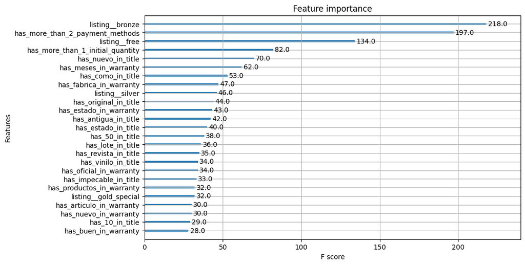

```python
# Plot feature importance
xgb.plot_importance(xgb_model_calibrated.estimator, max_num_features=25)
```

Some features could eventually BE REMOVED for **simplification and model improvements**. This **will not be done**, but in an ideal scenario, we test with fewer variables to **optimize the computational cost**.

# **Evaluate Model - Classes**

##### Accuracy and Precision

After all, let's check if our model reached the **expected Accuracy performance** (86% or more) and the **Precision** value for different **cut-off thresholds** to classify our target column *is_condition_new* in the **Calibrated Model**.

```python
try:
    # Empty list to store values
    metrics_threshold = []
    # Loop to itterate over cuts and folds predictions
    for cut in [i/10.0 for i in range(1, 10)]:
        for fold in range(0, len(calibrated_preds)):
            # Convert probabilities into classes from passing threshold 'i'
            predictions_cut = np.where(calibrated_preds[fold]["predictions"] > cut, 1, 0)
            # Calculating metrics
            accuracy = accuracy_score(calibrated_preds[fold]["true"], predictions_cut)
            precision = precision_score(calibrated_preds[fold]["true"], predictions_cut)
            recall = recall_score(calibrated_preds[fold]["true"], predictions_cut)
            # Results in a pandas dataframe
            results = pd.DataFrame({
                "threshold": f"cut_{cut}",
                "fold": f"fold_{fold}",
                "accuracy": accuracy,
                "precision": precision,
                "recall": recall
            }, index=[0])
            # Append values to list
            metrics_threshold.append(results)
    # Bind all dfs from list in a single dataframe
    metrics_threshold = pd.concat(metrics_threshold)
    # Group by threshold and calculate the mean of "accuracy" and "recall"
    metrics_threshold = metrics_threshold.groupby("threshold").mean().reset_index()
    # Rename metric columns with prefix
    metrics_threshold = metrics_threshold.rename(
        columns={
            'accuracy': 'mean_accuracy',
            'precision': 'mean_precision',
            'recall': 'mean_recall'
            }
        )
    # Execution success log
    log.info("Mean accuracy and recall by each threshold succesfully done!")
except ImportError:
    # Execution error log
    log.error("Something went wrong... Could not calculate mean accuracy and recall by each threshold.")
```

```
2023-02-28 12:54:14,107 - Logger - INFO - Mean accuracy and recall by each threshold succesfully done!
```

```python
# Display final results
metrics_threshold
```

|  | threshold | mean_accuracy | mean_precision | mean_recall |
| --- | --- | --- | --- | --- |
| 0 | cut_0.1 | 0.75 | 0.69 | 0.97 |
| 1 | cut_0.2 | 0.77 | 0.71 | 0.96 |
| 2 | cut_0.3 | 0.78 | 0.72 | 0.95 |
| 3 | cut_0.4 | 0.82 | 0.85 | 0.81 |
| 4 | cut_0.5 | 0.83 | 0.89 | 0.77 |
| 5 | cut_0.6 | 0.82 | 0.93 | 0.71 |
| 6 | cut_0.7 | 0.81 | 0.95 | 0.68 |
| 7 | cut_0.8 | 0.80 | 0.96 | 0.66 |
| 8 | cut_0.9 | 0.79 | 0.97 | 0.62 |

**Comments**: We did not reach the minimum accuracy, but we got VERY CLOSE (max of 83%). The probability predictions metrics are with **very satisfactory values** in the *Calibrated Model*, indicating that the outputs are considerably RELIABLE PROBABILITIES. Also, the **distance of metrics values and the standard deviations** between train and test set in every fold is QUITE SMALL, reinforcing a low indicator of **overfitting**.

When we convert them to class predictions, choosing the default threshold of **0.5**, we have a model with a GOOD ACCURACY and NO STRONG BIAS for the PRECISION and RECALL metrics. If I have to choose a threshold, I would still use the **0.5**. This cut-off keeps HIGHER ACCURACY, a HIGHER PRECISION and not a significant distance to the RECALL, showing a WELL BALANCED *Accuracy-Precision-Recall* comparasion. This relates to my initial thesis, trying to **reduce false positives**, but I DO NOT WANT to increase so much the **false negatives**.

Something that took my attention is that the *Precision and Recall* values show a **significant break** when considering cutoffs between **0.3-0.4**. Let's check the histograms from predictions probabilities.

```
2023-02-28 12:54:14,568 - Logger - INFO - Histogram plot from predictions succesfully done!
```

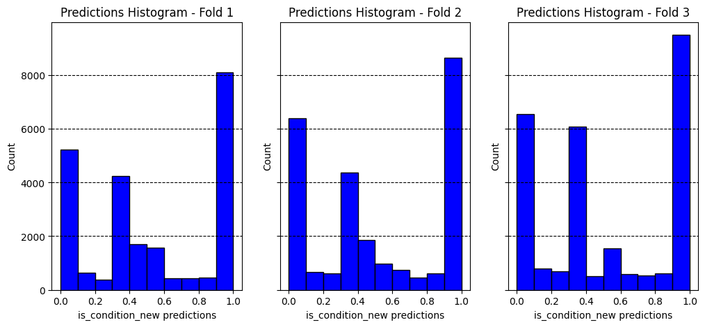

```python
# Plot histogram of predictions from Calibrated Model
proba_histograms(calibrated_preds)
```

**Comments:** As we can see, there is considerable **data accumulation** on these probabilities. The model possibly cannot distinguish these records well and therefore we reached the metric values presented above.

# **Creating a Rule**

I understand the requirement to reach a minimum percentage of accuracy for the model. However, given that the probabilities are VERY WELL CALIBRATED, I would assume that (IF I COULD) I make my business decision **based on the probabilities predictions**, even more so considering the large accumulation of records in the *0.3-0.4 interval* or even the *0.3-0.6 interval*, if you want to be more conservative. I believe that there is a **greater gain** in using the model if policies are created according to **probabilities**, rather than exclusively classifying products as 0 (*not new*) or 1 (*new*).

Based on this, we could STILL consider a product as *new* or *used*, but adding rules for different probabilities:

(a) If the seller sets the product as *used*, DO NOT INVOKE the model; It makes no sense to try to predict the condition of a product if the seller himself has established his product as *used*.

(b) But, if the seller sets the product as *new*, INVOKE the model and consider predictions in interval and the following rules (**JUST EXAMPLES**):

- *(0.0, 0.3]* <> **Provide an extended warranty at no cost to the buyer to ensure its new condition (considering the words from feature importance)**;
- *(0.3, 0.6]* <> **Inform that the seller needs to provide more data about the product to ensure the condition is new**;
- *(0.6, 1.0]* <> **Automatically classified as new**

If the seller executes the actions, call the model again, now with the update data.

# **Improvements**

After completing our entire *data science pipeline*, we can conclude that the points to be improved are:

1 - *New Filters*: Apply new filters on the dataset for **better selection of records** such as filtering by **seller address** (*Country*; *State*; etc.), by the **currency** used for purchase (just *ARS*), etc.

2 - *New Records*: The filtered data set for modeling is from a SMALL TIME INTERVAL, which impacts the folds split in **15 days**. As time passes, we will need to **retrain the model according to this range**, until we create a sufficient dataset to increase the date range between folds. In this way, we will have a more generalist model that requires less frequent retraining.

3 - *New Features*: I took a look at the Mercado Libre Developers API and realized that there is a **lot more information** that could have added too much to the model. **Sellers data**, **buyers feedback history**, and other information could further help in the product condition prediction process.

4 - *Text Features*: Certainly the biggest performance gain of the model was when extracting information about text variables. In the future, some **pre-trained NLP model** can be implemented to achieve the expected result. Or even simpler things like **TF-IDF**, **Word Embeddings**, etc.

5 - *Data Architecture*: Build a **Machine Learning pipeline** capable of performing **data wrangling, feature engineering, feature selection, detect shift, training models and predict values**.

# **Requirements**

```python
try:
    # Declaring path to file
    TEXT_FILE_NAME = 'requirements_ml.txt'
    text_path = os.path.join(os.path.dirname(os.getcwd()), TEXT_FILE_NAME)
    # Checking: If file exists, then drop it.
    if os.path.exists(text_path) == True:
        os.remove(text_path)
    # Creating txt file
    with open(file=text_path, mode="w", encoding="utf-8") as f:
        # Listing libraries and their version
        PACKAGES = '\n'.join(
            f'{m.__name__}=={m.__version__}' for m in globals().values() if getattr(m, '__version__', None)
        )
        # Writing information
        f.write(PACKAGES)
        # Closing final file
        f.close()
    # # Execution success log
    log.info(
        "File '%s' containing the list of packages to be installed succesfully built!",
        TEXT_FILE_NAME
    )
except ImportError:
    # Execution error log
    log.error(
        "Something went wrong... Could not build the list of packages to be installed in '%s' file.",
        TEXT_FILE_NAME
    )
```

```
2023-02-28 12:54:15,244 - Logger - INFO - File 'requirements_ml.txt' containing the list of packages to be installed succesfully built!
```